[figure not shown]

*Estadística y Probabilidades I*

**Nivel de satisfacción de los estudiantes de pregrado de UTEC respecto a las áreas verdes y/o de descanso en el periodo 2022-2**

## 1. Introducción

#### **1.1 Relevancia**

Con la vuelta a la presencialidad, se volvieron a utilizar diversas áreas de la universidad de ingeniería y tecnología (UTEC), áreas que los estudiantes usan para descansar o estudiar. Por lo tanto, algo interesante de estudiar es el impacto que tienen el uso de estas áreas con la sensación de aprendizaje del estudiante y la satisfacción del mismo sobre la disponibilidad y condiciones en las que se encuentran.

Y aunque sería más interesante poder evaluar la existencia de un efecto directo entre el uso de estos espacios con el desempeño académico, es imposible en este momento debido a la ausencia de data de un ciclo inmediato previo presencial.

#### **1.2 Planificación**

De esta forma se analizará la relación que existe entre la frecuencia de uso y la sensación de aprendizaje del estudiante, para determinar la eficiencia, insuficiencia o falta de aforo para los estudiantes.

## 2. Objetivo

#### **2.1. Objetivo general**

Determinar el nivel de satisfacción de los estudiantes de pregrado de UTEC respecto a las áreas verdes y de descanso en el campus de la universidad en el periodo 2022-2.

#### **2.2. Objetivos específicos**

- Determinar los lugares más concurridos en la universidad para descansar y/o estudiar.
- Determinar el tiempo aproximado por personas que se pasa en dichas áreas.
- Describir qué tan cómodas son estas áreas para el alumnado y posibles mejoras para mejorar dichas áreas.
- Conocer si las áreas destinadas al estudio como áreas verdes son suficientes para los estudiantes de UTEC.
- Analizar la relación del tiempo que se pasa en estas áreas con el nivel de comodidad en estos.

## 3. Hipótesis

El nivel de satisfacción de los estudiantes respecto a esta áreas está relacionado directamente con la comodidad de estas y el tiempo que los estudiantes pasan en dichas áreas.

## 4. Marco Teórico

#### **4.1. Definiciones importantes**

- **NPS:** El Net Promoter Score es un sistema indicador del nivel de satisfacción del cliente, mayormente es usado en el área de Marketing.

#### **4.2. Población**

Los estudiantes de pregrado de la universidad de ingeniería y tecnología (UTEC).

#### **4.3. Muestra y tipo de Muestreo**

Utilizaremos una muestra de 200 alumnos de la UTEC a través de un muestreo aleatorio simple (MAS)

## 5. Datos

#### **5.1. Recolección de datos**

La recolección de datos se realizó mediante una encuesta virtual en la plataforma de google forms y se difundió en su mayoría vía web, pero también de manera presencial mediante interceptación de los estudiantes.

Link de la encuesta: https://forms.gle/XQsvTmgDLa7yU6kG7

#### **5.2. Clasificación de Variables**

##### **5.2.1. Variables Categóricas**

| Variable | Tipo de Variable | Restricciones |
| --- | --- | --- |
| Sexo | Categórica nominal | Femenino o Masculino |
| Carrera | Categórica nominal | De las opciones |
| Lugares de estudio | Categórica nominal | De las opciones |
| Dias frecuentes | Categórica ordinal | De Lunes a Sabado |
| Incomodiades | Categórica nominal | De las opciones |
| Aumento de áreas | Categórica nominal | Ambas, ninguna, solo areas verdes o solo areas de descanso |

##### **5.2.2. Variables Numéricas**

| Variable | Tipo de Variable | Restricciones |
| --- | --- | --- |
| Edad | Numérica discreta | entero mayor de 13 |
| Ciclo actual | Numérica discreta | Numero entero del 1 al 10 |
| Tiempo de estudio | Numérica discreta | Numero entero en horas |
| Indice de accesibilidad | Numérica discreta | Del 1 al 10 |
| Indice de comodidad | Numérica discreta | Del 1 al 10 |
| Nivel de concentración | Numérica discreta | Del 1 al 10 |
| Nivel de apoyo percibido por estas áreas | Numérica discreta | Del 1 al 10 |

## 6. Limpieza de datos

#### **6.1. Importando librerías**

```r
library(ggplot2)
library(readr)
library(dplyr)
library(stringr)
library(graphics)
library(tidyr)
library(modeest)
library(reshape2)
```

#### **6.2. Cargando la data**

```r
datos<-read_csv("importancia.csv")
```

```
## -------------------------------------------------------- Delimiter: "," chr
## (9): Marca temporal, Nombres:, Apellidos:, Sexo:, Carrera:, Lugares frec... dbl
## (8): Código:, Edad:, Ciclo actual:, ¿Cuantas horas a la semana usas esto... lgl
## (1): ...2
```

##### **Creando funciones**

```r
fixh <- function(tuple) {
    #' retira el head del dataframe de una osla fila, asi se convertirá en un arreglo con solo los valores.
    names(tuple) <- NULL;  return (tuple);
}
#' redondeo de un decimal
rd3 <- function(x) {  return (round(x, 3)); }
```

Algunas variables del Google Forms contienen mutiples respuestas separados por comas, entonces se tendrá que recopilar cada observación en spliteo entre comas para una variable categórica como una columna de 1 o 0 con la función `separate_var`.

```r
separate_var <- function(data, variable, refer) {
    part <- paste("", refer, sep ="")
    for(i in 1: length(refer)) {
        data[part[i]] <- as.numeric(str_detect(variable, refer[i]))
    }; return (data)
}
```

#### **6.3. Renombrando variables**

Se cambia los nombres de las variables para que sean más sencillas de utilizar en la creación de los diagramas a estudiarse.

```r
part <- c("nombre" , "apellido" , "codigo" , "edad" , "sexo" , "ciclo" , "carrera" , "lugares" , "horasS" , "accesibilidad" , "dias" , "comodidad" , "incomodidad" , "aumentos" , "concentracion" , "apoyo")
#' seleccionando las columnas necesarias
datos <- datos[3:18]
colnames(datos) <- part
names(datos)
```

```
##  [1] "nombre"        "apellido"      "codigo"        "edad"
##  [5] "sexo"          "ciclo"         "carrera"       "lugares"
##  [9] "horasS"        "accesibilidad" "dias"          "comodidad"
## [13] "incomodidad"   "aumentos"      "concentracion" "apoyo"
```

```r
datos1<-datos[,-1]
```

#### **6.4. Reasignación de datos**

Creamos una lista donde detallamos los símbolos que deseamos quitar, como las tildes y espacios para que no aparezcan en nuestras observaciones y simplificar su uso.

```r
cambios <- c( " "="", "á"="a"
            , "é"="e", "í"="i")
datos$lugares %>% str_replace_all(cambios) -> datos$lugares
datos$dias %>% str_replace_all(cambios) -> datos$dias
datos$incomodidad %>% str_replace_all(cambios) -> datos$incomodidad
```

## 7. Análisis descriptivo

#### **7.1. Variables Categóricas**

##### **Sexo**

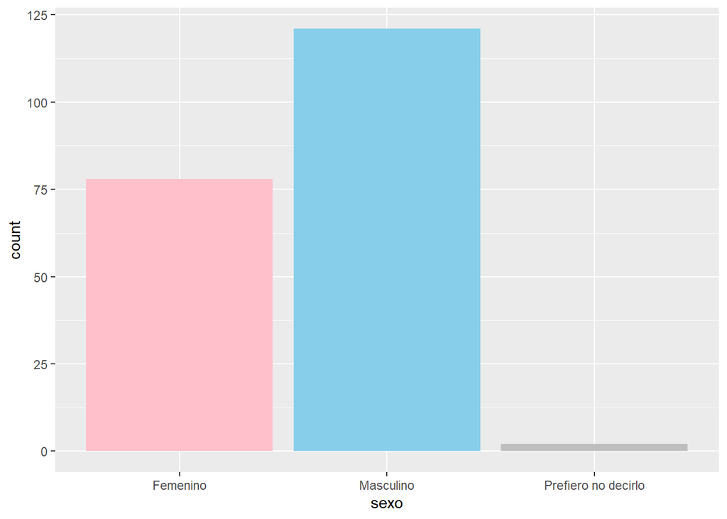

```r
ggplot(datos, aes(x=sexo)) +geom_bar(fill= c("pink","skyblue","gray"))
```

Como primera gráfica tenemos una que nos permite deducir que el género predominante entre los estudiantes de UTEC, el cual resulto ser el masculino.

##### **Carrera**

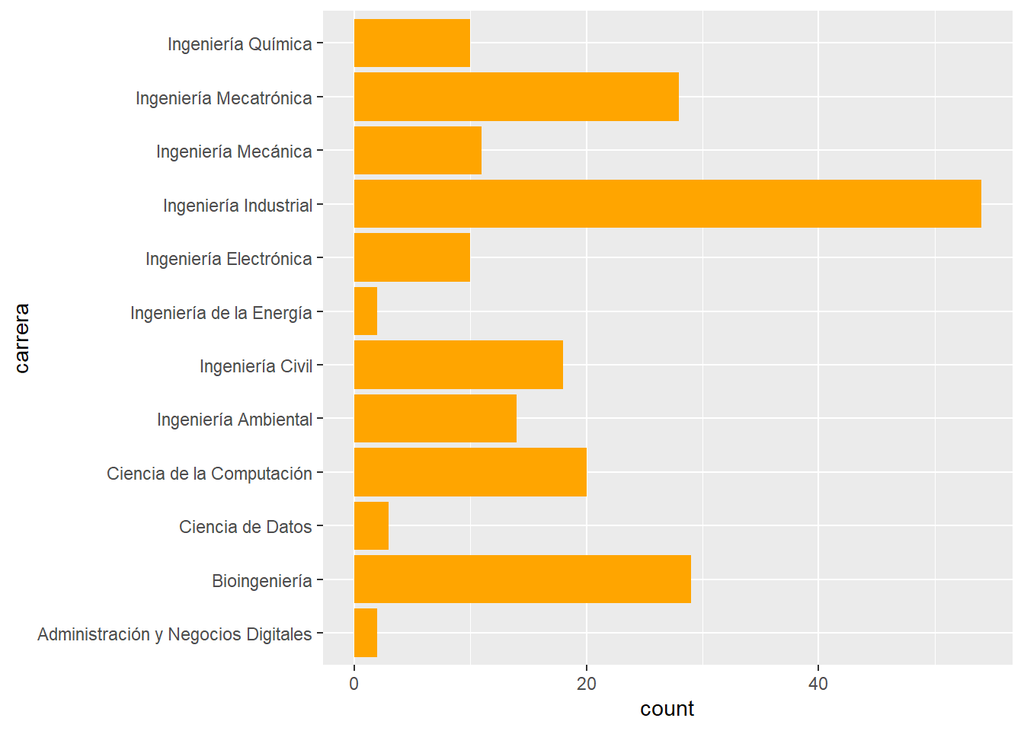

```r
ggplot(datos,aes(x=carrera)) +geom_bar(fill="orange")+ coord_flip()
```

##### **Ciclo**

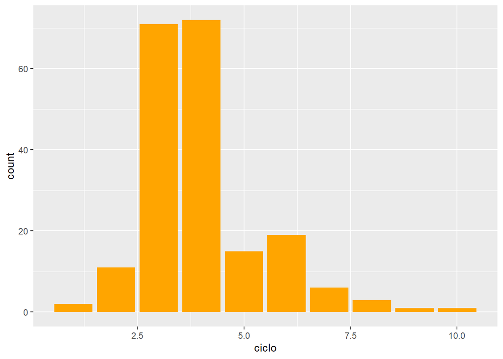

```r
ggplot(datos,aes(x=ciclo)) +geom_bar(fill="orange")
```

##### **Lugares frecuentes**

```r
lug <- c("Comedor", "Cubiculos-Piso8"
         , "Saladeestudio-Piso1", "Piso6"
         , "Biblioteca", "Aulaslibres"
         , "Piso11", "Saladepingpong", "Otros")
```

```r
datos_lug <- separate_var(datos, datos$lugares, lug)
```

```r
lugar_des <- c(sum(datos_lug$Comedor), sum(datos_lug$`Cubiculos-Piso8`)
               , sum(datos_lug$`Saladeestudio-Piso1`), sum(datos_lug$Piso6)
               , sum(datos_lug$Biblioteca), sum(datos_lug$Aulaslibres)
               , sum(datos_lug$Piso11), sum(datos_lug$Saladepingpong), sum(datos_lug$Otros))
reg_lugar <- data.frame(name = lug, frec = lugar_des)
part <- paste("DeEn_", lug, sep ="")
for(i in 1: length(lug)){
  datos1[part[i]] <- as.numeric(str_detect(datos$lugares, lug[i]))
}
```

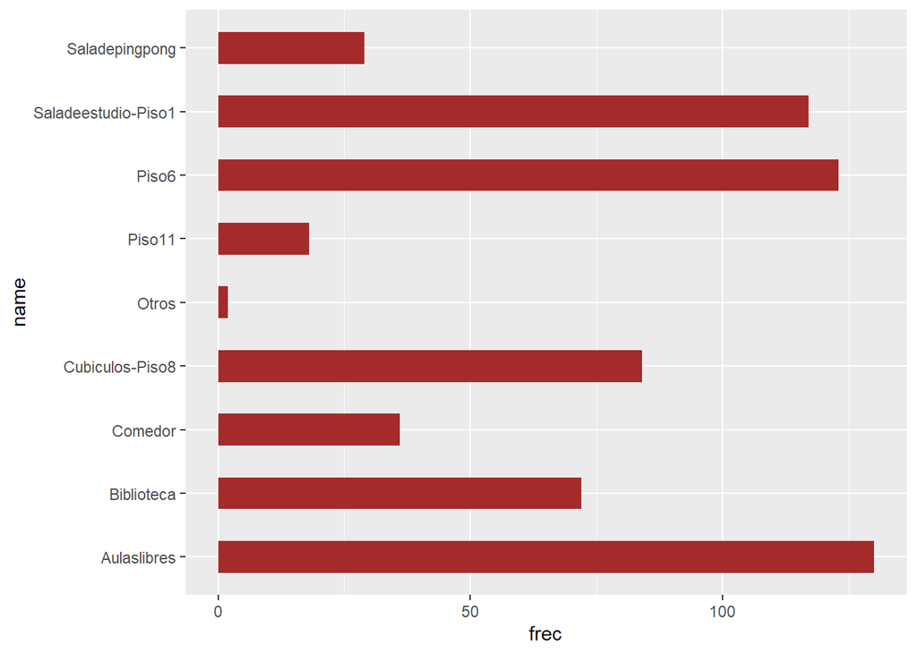

```r
ggplot(reg_lugar, aes(x=name, y=frec)) + geom_bar(stat="identity", fill="brown", width = 0.5)+ coord_flip()
```

Lo que podemos deducir a partir de esta gráfica es que los estudiantes de Utec prefieren pasar su tiempo libre tanto para estudiar como para descansar en las aulas libres del campus, pero seguido a esto observamos que la sala de estudio, situada en el piso 1, y las mesas en el piso 6 también son muy concurridos por los estudiantes.

##### **Días frecuentes**

```r
dia <- c("Lunes", "Martes", "Miercoles", "Jueves"
         , "Viernes", "Sabado")
```

```r
datos_dia <- separate_var(datos, datos$dias, dia)
```

```r
dia_des <- c(sum(datos_dia$Lunes), sum(datos_dia$Martes)
            , sum(datos_dia$Miercoles), sum(datos_dia$Jueves)
            , sum(datos_dia$Viernes), sum(datos_dia$Sabado))
reg_dia <- data.frame(name = dia, frec = dia_des)
reg_dia
```

| name | frec |
| --- | --- |
| Lunes | 73 |
| Martes | 89 |
| Miercoles | 68 |
| Jueves | 93 |
| Viernes | 64 |
| Sabado | 13 |

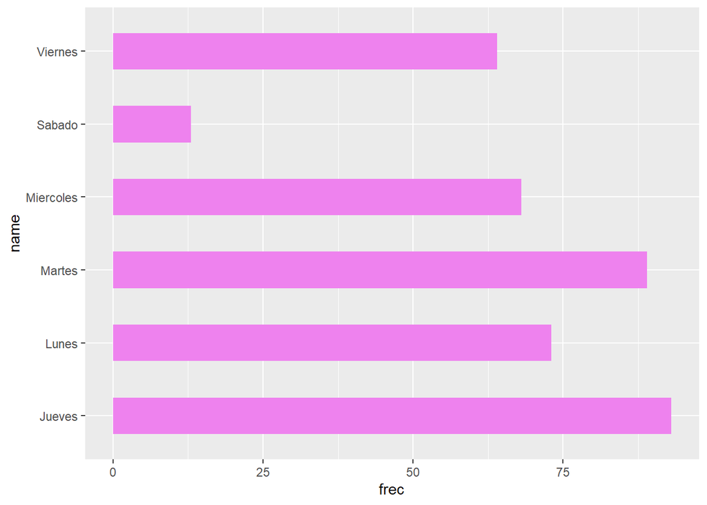

```r
ggplot(reg_dia, aes(x=name, y=frec)) + geom_bar(stat="identity", fill="violet", width = 0.5)+ coord_flip()
```

Según esta gráfica podemos observar que los días lunes, martes, miercoles, jueves y viernes no tienen mucha diferencia en cuanto al tamaño de sus barras, pero observamos que el día sábado sí hay una gran diferencia respecto a los otros, esto es debido a que la cantidad de estudiantes que estan en el campus los días sabado es menor respecto a los otros días.

##### **Motivos por los cuales no se eligen estos espacios**

```r
incomoda <- c("Faltadeespacio", "Demasiadoruido"
              , "Faltadeenchufes", "Bajavelocidaddelinternet"
              , "Pocadisponibilidaddeloscubiculos", "Otros")
```

```r
datos_inc <- separate_var(datos, datos$incomodidad, incomoda)
```

```r
incomoda_des <- c(sum(datos_inc$Faltadeespacio), sum(datos_inc$Demasiadoruido)
            , sum(datos_inc$Faltadeenchufes), sum(datos_inc$Bajavelocidaddelinternet)
            , sum(datos_inc$Pocadisponibilidaddeloscubiculos), sum(datos_inc$Otros))
reg_incomoda <- data.frame(name = incomoda, frec = incomoda_des)
```

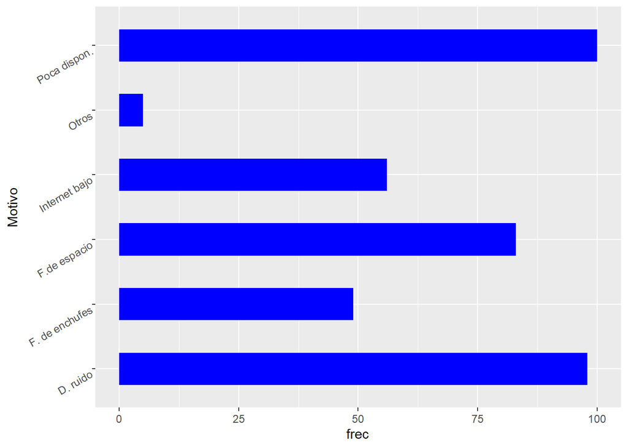

```r
ggplot(reg_incomoda, aes(x=c("F.de espacio", "D. ruido", "F. de enchufes", "Internet bajo", "Poca dispon.", "Otros"), y=frec)) +
        geom_bar(stat="identity", fill="blue", width = 0.5)+ coord_flip() +
        theme(axis.text.y = element_text(angle = 30, vjust = 1)) + labs(x = "Motivo")
```

Observamos que en esta gráfica “la poca disponibilidad” y “la cantidad de ruido” en estos espacios son las incomodidades que más han presentado los estudiantes respecto a estos espacios.

##### **Opinión de los estudiantes sobre aumentos de estas áreas**

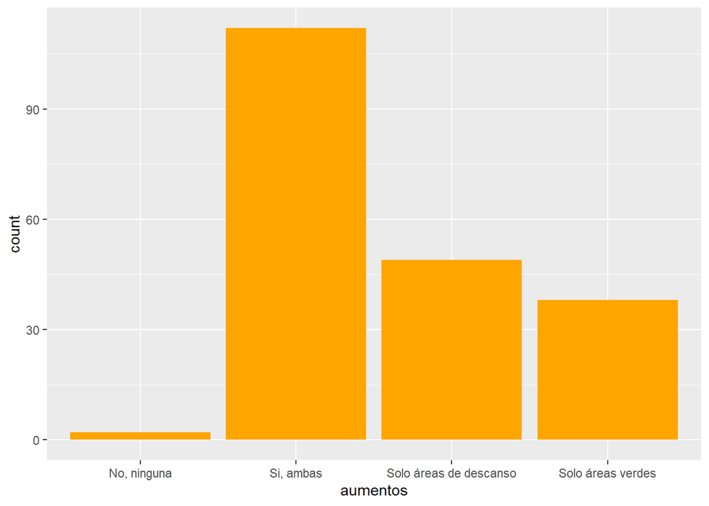

```r
ggplot(datos,aes(x=aumentos)) +geom_bar(fill="orange")
```

Según esta gráfica gran parte de estudiantes al cuales se les realizó la encuesta, coinciden en que deberian aumentarse ambas áreas.

#### **7.2. Variables Numéricas**

##### **Edad**

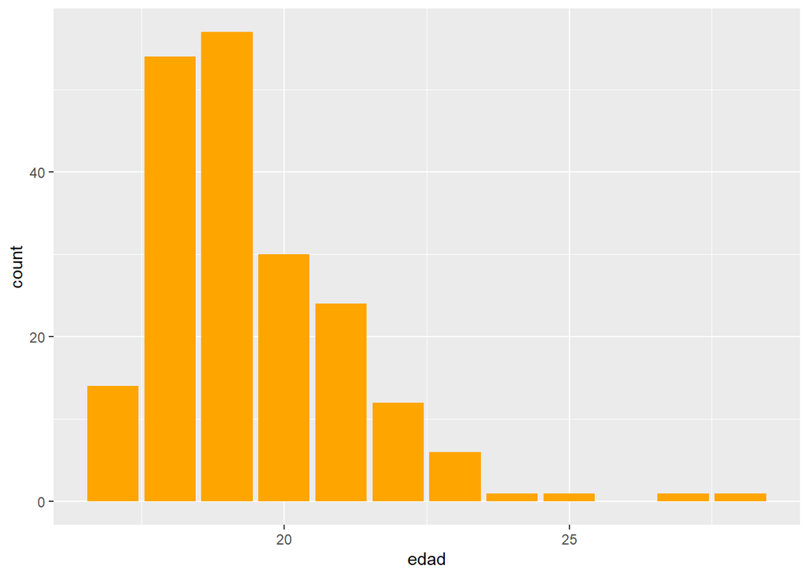

```r
ggplot(datos,aes(x=edad)) +geom_bar(fill="orange")
```

##### **Horas de permanencia**

- Los estudiantes recurren a estos lugares en un tiempo promedio de 9.473 horas.
- Aproximadamente el 50% de los estudiantes recurren por debajo de 8 horas y los otro 50% encima de este tiempo.

```r
q25 <- quantile(datos$horasS, 0.25)
q75 <- quantile(datos$horasS, 0.75)
itq <- IQR(datos$horasS)
```

```r
no_atip <- filter(datos, horasS >= q75+1.5*itq)
```

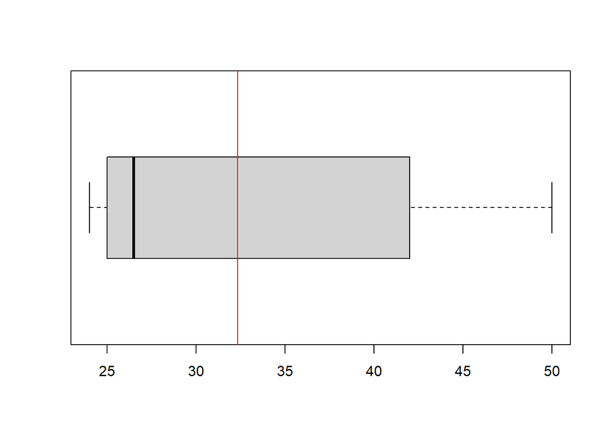

```r
boxplot(no_atip$horasS, horizontal = TRUE)
abline(v = c(mean(no_atip$horasS)), col = "red")
```

##### **Grado de comodidad y accesibilidad de estos espacios**

Juntamos ambas variables tomando como factor de frecuencia los grados del 1 al 10.

```r
com_acc <- merge(x = data.frame(table(datos$comodidad)), y = data.frame(table(datos$accesibilidad)), by = c("Var1"))
names(com_acc) <- c("Grado", "Comodidad", "Accesibilidad")
com_shape <- melt(com_acc, id='Grado')
```

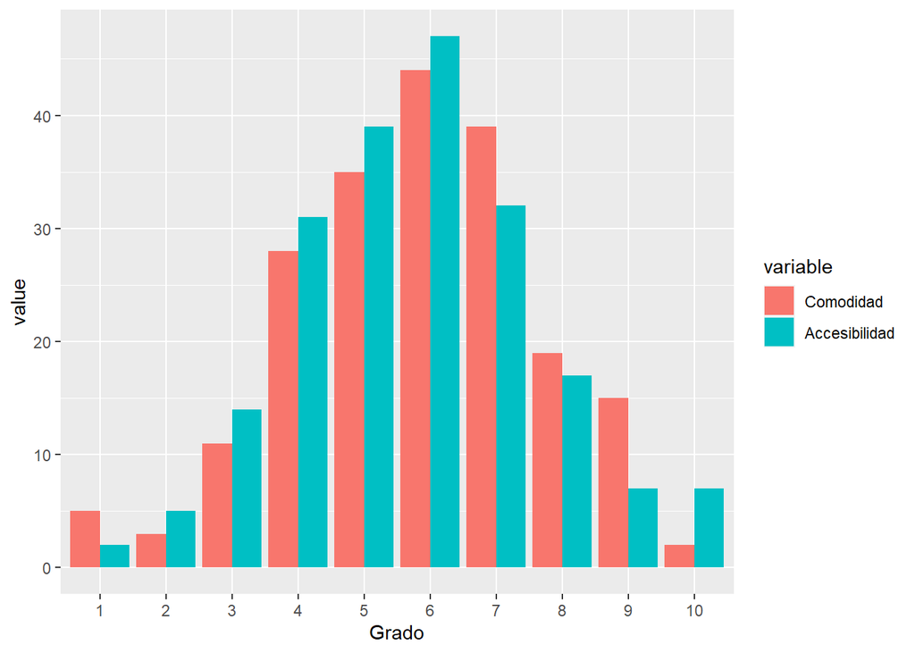

```r
ggplot(com_shape, aes(Grado, value, fill=variable, group=variable)) +
        geom_bar(stat='identity', position='dodge')
```

##### **Grado de concentración y nivel de apoyo de estos espacios**

```r
com_apo <- merge(x = data.frame(table(datos$concentracion)), y = data.frame(table(datos$apoyo)), by = c("Var1"))
names(com_apo) <- c("Grado", "Concentración", "Apoyo")
com_shape <- melt(com_apo, id='Grado')
```

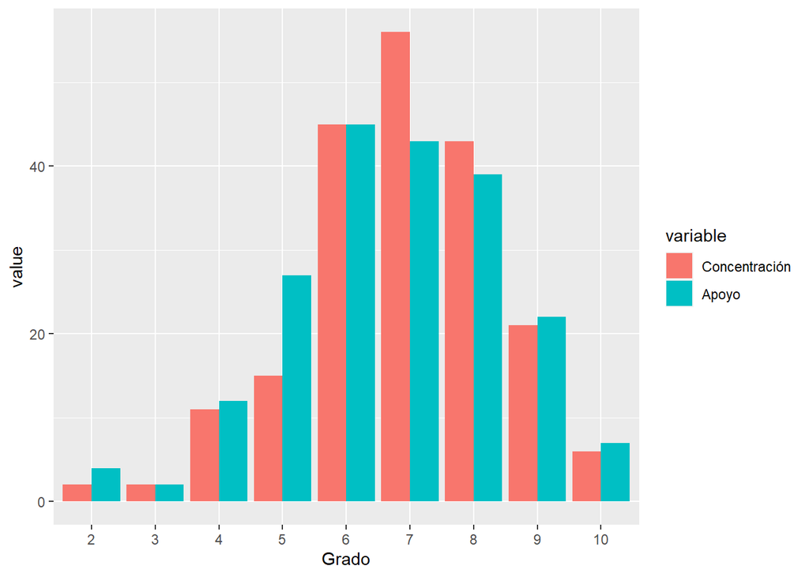

```r
ggplot(com_shape, aes(Grado, value, fill=variable, group=variable)) +
        geom_bar(stat='identity', position='dodge')
```

#### **7.3. Relacion entre variables**

##### **Carrera vs. accesibilidad de los espacios**

```r
carreras <- c(unique(datos$carrera))
newcarreras <- c("Ing. Mecan", "Ing. Mecatr", "Ing. Indus", "Ing. Energ", "Ing. Quim", "Bioing", "Ing. Civil", "CS", "Ing. Elec", "Ing. Amb", "Admin", "DS")
for (it in 1:length(carreras)) {
    datos$carrera[datos$carrera == carreras[it]] <- newcarreras[it]
}
```

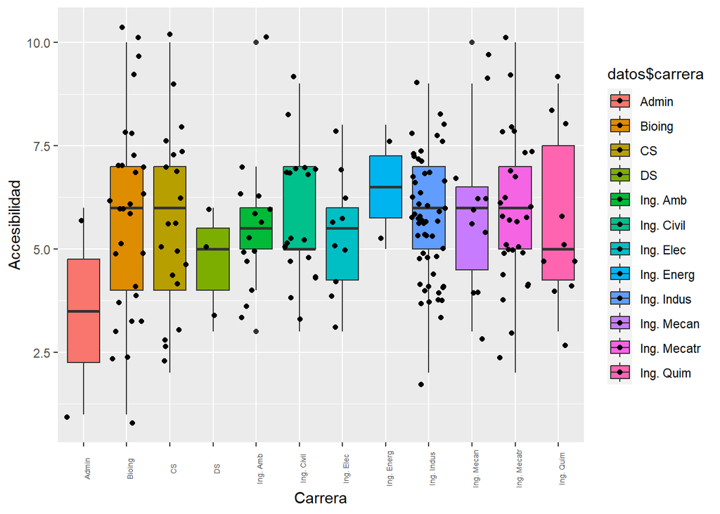

```r
qplot(datos$carrera, datos$accesibilidad, data=datos, geom=c("boxplot","jitter"),
      fill=datos$carrera, xlab = "Carrera", ylab = "Accesibilidad") +
      theme(axis.text.x = element_text(size=rel(0.6), angle = 90))
```

##### **Sexo vs. aporte académico**

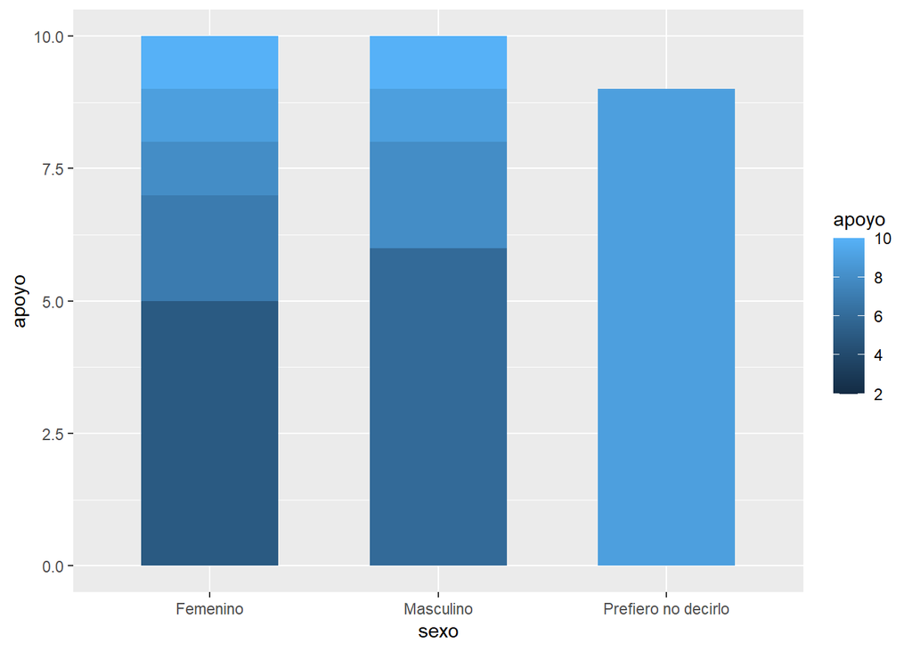

```r
ggplot(datos, aes(x=sexo,y=apoyo, fill=apoyo)) + geom_col(position="dodge", width = 0.6)
```

Aquí, equitativamente, tanto en hombres como en mujeres existen puntos de vista variados acerca del apoyo.

##### **Dias vs. accesibilidad de los espacios**

```r
acc_dia <- datos_dia %>% group_by(accesibilidad) %>%
            summarise(lunes = sum(Lunes),martes = sum(Martes),
                    miercoles = sum(Miercoles), jueves = sum(Jueves),
                    viernes = sum(Viernes), sabado = sum(Sabado))
```

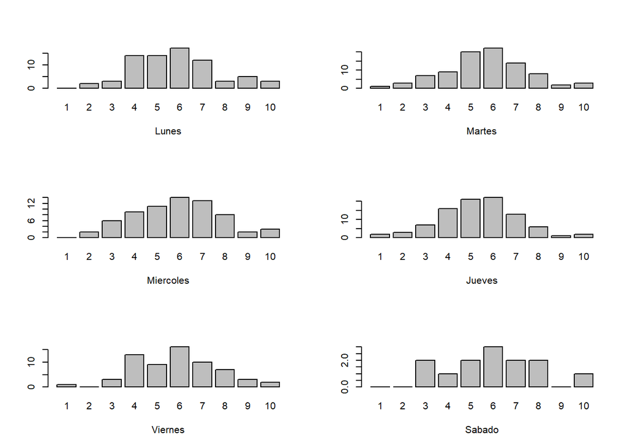

```r
par(mfrow=c(3,2))
barplot(acc_dia$lunes, names.arg = acc_dia$accesibilidad, xlab = "Lunes")
barplot(acc_dia$martes, names.arg = acc_dia$accesibilidad, xlab = "Martes")
barplot(acc_dia$miercoles, names.arg = acc_dia$accesibilidad, xlab = "Miercoles")
barplot(acc_dia$jueves, names.arg = acc_dia$accesibilidad, xlab = "Jueves")
barplot(acc_dia$viernes, names.arg = acc_dia$accesibilidad, xlab = "Viernes")
barplot(acc_dia$sabado, names.arg = acc_dia$accesibilidad, xlab = "Sabado")
```

##### **Carrera vs. horas de permanencia a la semana**

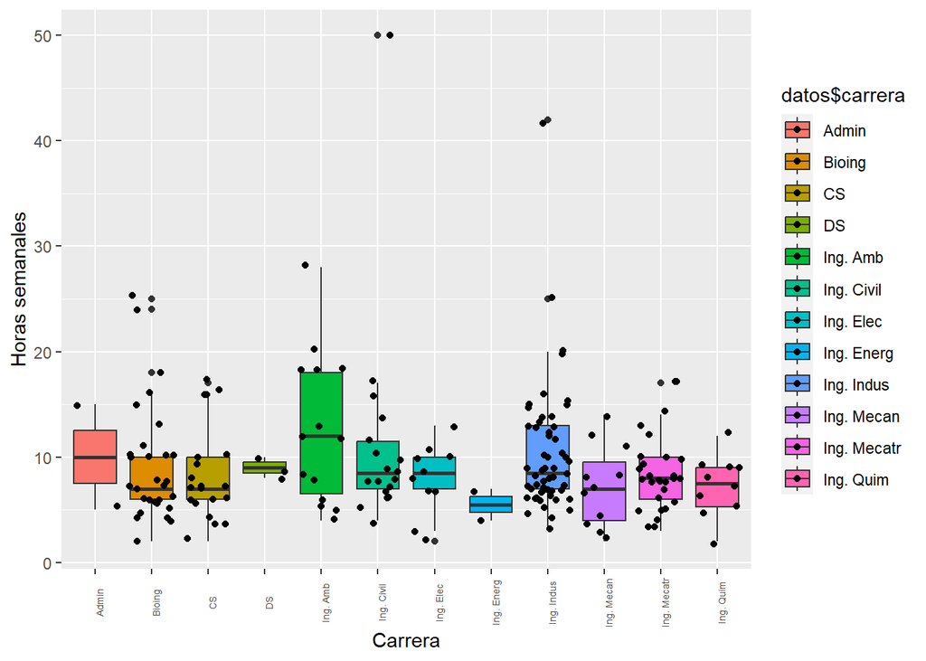

```r
qplot(datos$carrera, datos$horasS, data=datos, geom=c("boxplot","jitter"),
      fill=datos$carrera, xlab = "Carrera", ylab = "Horas semanales") +
      theme(axis.text.x = element_text(size=rel(0.6), angle = 90))
```

## 8. Variables aleatorias

- Edad
- Horas frecuentes
- Accesibilidad de los lugares
- Grado de comodidad y concentración
- Grado de apoyo

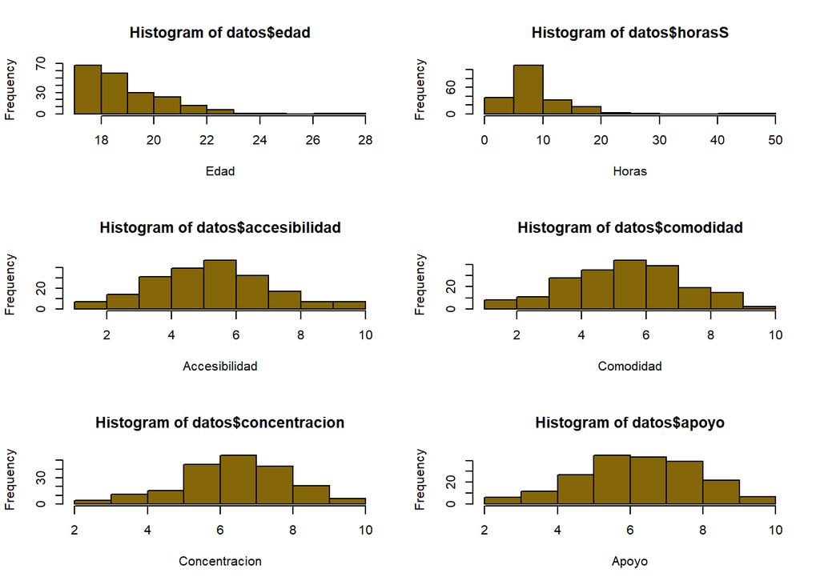

```r
par(mfrow=c(3,2))
hist(datos$edad, xlab = 'Edad',breaks = 10, freq = TRUE,col = "#856609")
hist(datos$horasS, xlab = 'Horas',breaks = 10, freq = TRUE,col = "#856609")
hist(datos$accesibilidad, xlab = 'Accesibilidad',breaks = 10, freq = TRUE,col = "#856609")
hist(datos$comodidad, xlab = 'Comodidad',breaks = 10, freq = TRUE,col = "#856609")
hist(datos$concentracion, xlab = 'Concentracion',breaks = 10, freq = TRUE,col = "#856609")
hist(datos$apoyo, xlab = 'Apoyo',breaks = 10, freq = TRUE,col = "#856609")
```

## 9. Gráfica con histograma y densidad

#### **9.1. Modelo exponencial - Variable Edad**

```r
summary(datos$edad)
```

```
##    Min. 1st Qu.  Median    Mean 3rd Qu.    Max.
##   17.00   18.00   19.00   19.42   20.00   28.00
```

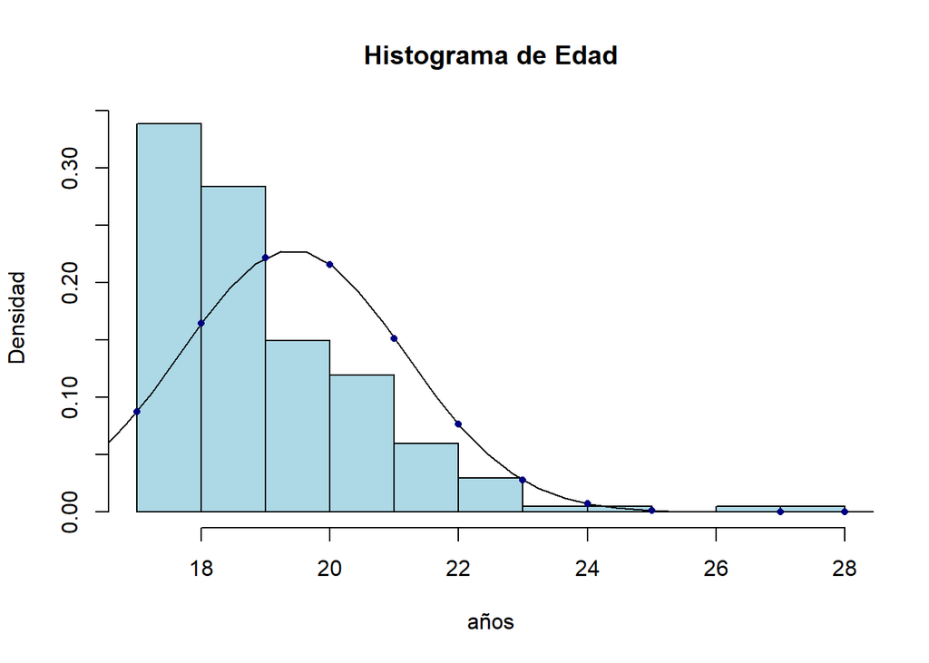

```r
hist(datos$edad, breaks=10, freq = FALSE, main="Histograma de Edad",xlab="años",ylab = "Densidad", col = "lightblue")
curve(dnorm(x, mean(datos$edad,na.rm = TRUE), sd = sd(datos$edad,na.rm = TRUE)),
      0, 200, 500,
      yaxs = "i", add = TRUE)
points(datos$edad, dnorm(datos$edad, mean(datos$edad,na.rm = TRUE), sd = sd(datos$edad,na.rm = TRUE)), ylab = "f(x)", pch = 20,  lwd = 0.1, col = "navyblue")
```

```r
desv_edad <- rd3(sd(datos$edad , na.rm = TRUE))
round(desv_edad,digits=2)
```

```
## [1] 1.75
```

```r
cv_edad <-rd3((sd(datos$edad, na.rm = TRUE)/mean(datos$edad, na.rm = TRUE)))
round(cv_edad,digits=2)
```

```
## [1] 0.09
```

- Graficamente podemos observar que esta variable tiene un comportamiento exponencial, a pesar de que la media, mediana y moda son parecidas.
- El parecido entre la mediana y la media se debe a que hay mucha concentración de datos entre los 18 y 20 años, esto probablemente se debe a que la población encuestada es contemporánea a los estudiantes encargados de este proyecto, esta gran concentracion hace que ocurra una variación muy significativa entre dos dato (20-21), por lo que la grifica tambien muestra una curva con caracter “normal”.
- La desviacion estandar es pequeña (1.748`), entonces la variablidad de edades es minima.
- El coeficiente de variación es mínimo (0.09`), lo que nos revela que exite gran homogeneidad entre los datos.

#### **9.2. Modelo normal - Variable Horas**

```r
summary(datos$horasS)
```

```
##    Min. 1st Qu.  Median    Mean 3rd Qu.    Max.
##   2.000   6.000   8.000   9.473  12.000  50.000
```

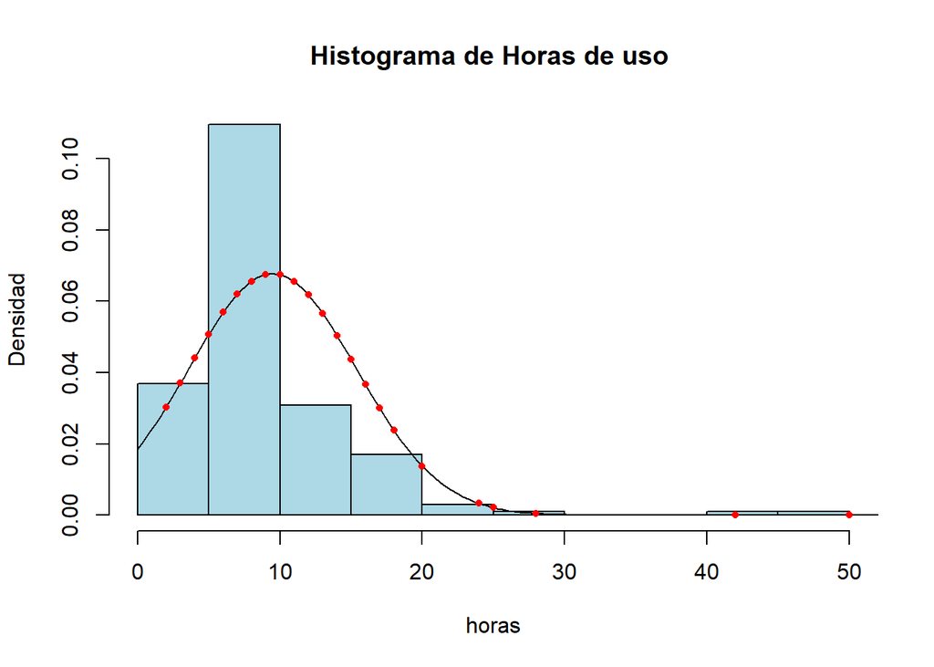

```r
hist(datos$horasS, breaks=10, freq = FALSE, main="Histograma de Horas de uso ",xlab="horas",ylab = "Densidad", col = "lightblue")
curve(dnorm(x, mean(datos$horasS,na.rm = TRUE), sd = sd(datos$horasS,na.rm = TRUE)),
      0, 200, 500,
      yaxs = "i", add = TRUE)
points(datos$horasS, dnorm(datos$horasS, mean(datos$horasS,na.rm = TRUE), sd = sd(datos$horasS,na.rm = TRUE)), ylab = "f(x)", pch = 20,  lwd = 0.1, col = "red")
```

```r
desv_hor <- rd3(sd(datos$horasS , na.rm = TRUE))
round(desv_hor,digits=2)
```

```
## [1] 5.9
```

```r
cv_hor <-rd3((sd(datos$horasS, na.rm = TRUE)/mean(datos$horasS, na.rm = TRUE)))
round(cv_hor,digits=2)
```

```
## [1] 0.62
```

#### **9.3. Modelo normal - Variable Accesibilidad**

```r
summary(datos$accesibilidad)
```

```
##    Min. 1st Qu.  Median    Mean 3rd Qu.    Max.
##   1.000   4.000   6.000   5.711   7.000  10.000
```

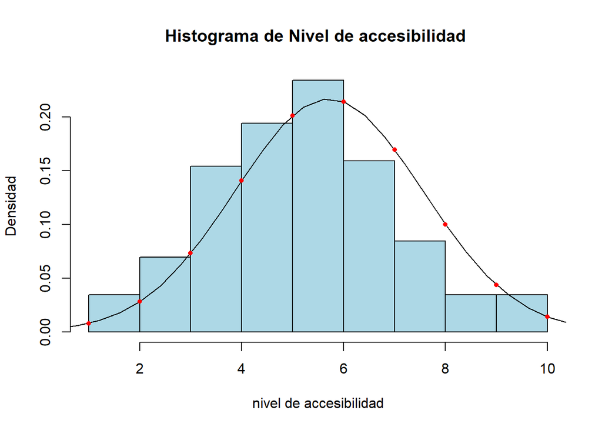

```r
hist(datos$accesibilidad, breaks=10, freq = FALSE, main="Histograma de Nivel de accesibilidad ",xlab = "nivel de accesibilidad",ylab = "Densidad", col = "lightblue")
curve(dnorm(x, mean(datos$accesibilidad,na.rm = TRUE), sd = sd(datos$accesibilidad,na.rm = TRUE)),
      0, 200, 500,
      yaxs = "i", add = TRUE)
points(datos$accesibilidad, dnorm(datos$accesibilidad, mean(datos$accesibilidad,na.rm = TRUE), sd = sd(datos$accesibilidad,na.rm = TRUE)), ylab = "f(x)", pch = 20,  lwd = 0.1, col = "red")
```

```r
desv_acc <- rd3(sd(datos$accesibilidad , na.rm = TRUE))
round(desv_acc,digits=2)
```

```
## [1] 1.84
```

```r
cv_acc <-rd3((sd(datos$accesibilidad, na.rm = TRUE)/mean(datos$accesibilidad, na.rm = TRUE)))
round(cv_acc,digits=2)
```

```
## [1] 0.32
```

#### **9.4. Modelo normal - Variable Comodidad**

```r
summary(datos$comodidad)
```

```
##    Min. 1st Qu.  Median    Mean 3rd Qu.    Max.
##   1.000   5.000   6.000   5.846   7.000  10.000
```

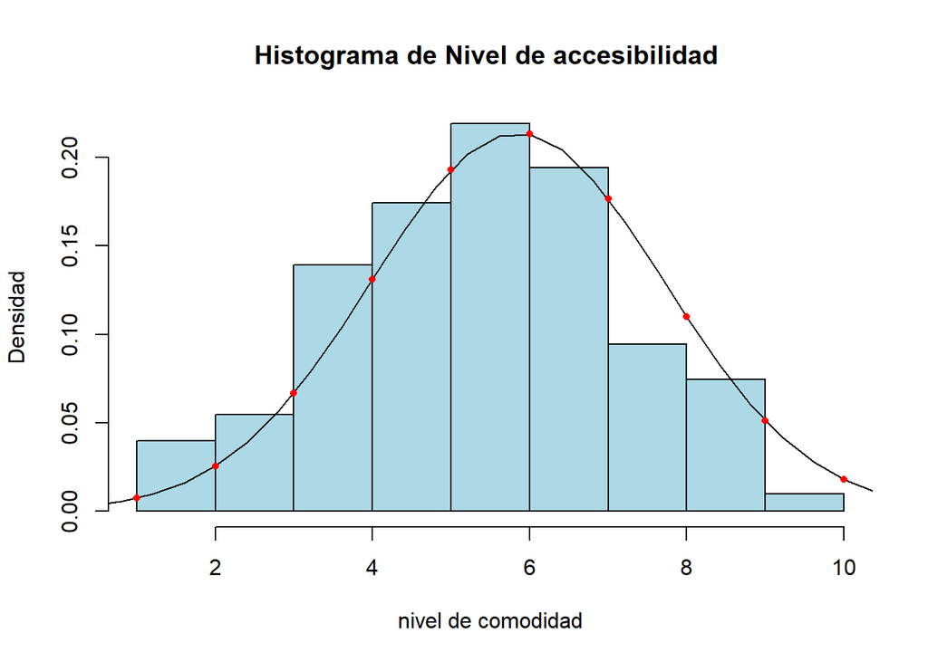

```r
hist(datos$comodidad, breaks=10, freq = FALSE, main="Histograma de Nivel de accesibilidad ",xlab = "nivel de comodidad",ylab = "Densidad", col = "lightblue")
curve(dnorm(x, mean(datos$comodidad,na.rm = TRUE), sd = sd(datos$comodidad,na.rm = TRUE)),
      0, 200, 500,
      yaxs = "i", add = TRUE)
points(datos$comodidad, dnorm(datos$comodidad, mean(datos$comodidad,na.rm = TRUE), sd = sd(datos$comodidad,na.rm = TRUE)), ylab = "f(x)", pch = 20,  lwd = 0.1, col = "red")
```

```r
desv_com <- rd3(sd(datos$comodidad , na.rm = TRUE))
round(desv_com,digits=2)
```

```
## [1] 1.87
```

```r
cv_com <-rd3((sd(datos$comodidad, na.rm = TRUE)/mean(datos$comodidad, na.rm = TRUE)))
round(cv_com,digits=2)
```

```
## [1] 0.32
```

- Graficamente podemos observar que esta variable tiene un comportamiento normal, cumple con el criterio de la media, mediana y moda, el cual nos indica que estas tienen que ser similares.
- La desviacion estandar es pequeña (1.87), entonces la variablidad en el nivel de comodidad percibida es minima.
- El coeficiente de variación es pequeño (0.32), lo que nos revela que existe gran homogeneidad entre los datos.

#### **9.5. Modelo normal - Variable concentracion**

```r
summary(datos$concentracion)
```

```
##    Min. 1st Qu.  Median    Mean 3rd Qu.    Max.
##   2.000   6.000   7.000   6.886   8.000  10.000
```

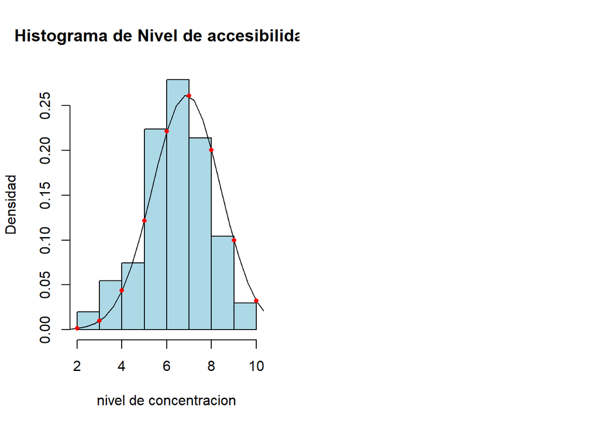

```r
op=par(mfrow=c(1,2))

hist(datos$concentracion, breaks=10, freq = FALSE, main="Histograma de Nivel de accesibilidad ",xlab = "nivel de concentracion",ylab = "Densidad", col = "lightblue")
curve(dnorm(x, mean(datos$concentracion,na.rm = TRUE), sd = sd(datos$concentracion,na.rm = TRUE)),
      0, 200, 500,
      yaxs = "i", add = TRUE)
points(datos$concentracion, dnorm(datos$concentracion, mean(datos$concentracion,na.rm = TRUE), sd = sd(datos$concentracion,na.rm = TRUE)), ylab = "f(x)", pch = 20,  lwd = 0.1, col = "red")
par(op)
```

```r
desv_concen <- rd3(sd(datos$concentracion , na.rm = TRUE))
round(desv_concen,digits=2)
```

```
## [1] 1.52
```

```r
cv_concen<-rd3((sd(datos$concentracion, na.rm = TRUE)/mean(datos$concentracion, na.rm = TRUE)))
round(cv_concen,digits=2)
```

```
## [1] 0.22
```

- Graficamente podemos observar que esta variable tiene un comportamiento normal, cumple con el criterio de la media, mediana y moda, el cual nos indica que estas tienen que ser similares.
- La desviacion estandar es pequeño (1.52), entonces la variablidad del nivel de concentración es minima.
- El coeficiente de variación es pequeña (0.22), lo que nos revela que existe gran homogeneidad entre los datos.

#### **9.6. Modelo normal - Variable Apoyo**

```r
summary(datos$apoyo)
```

```
##    Min. 1st Qu.  Median    Mean 3rd Qu.    Max.
##   2.000   6.000   7.000   6.706   8.000  10.000
```

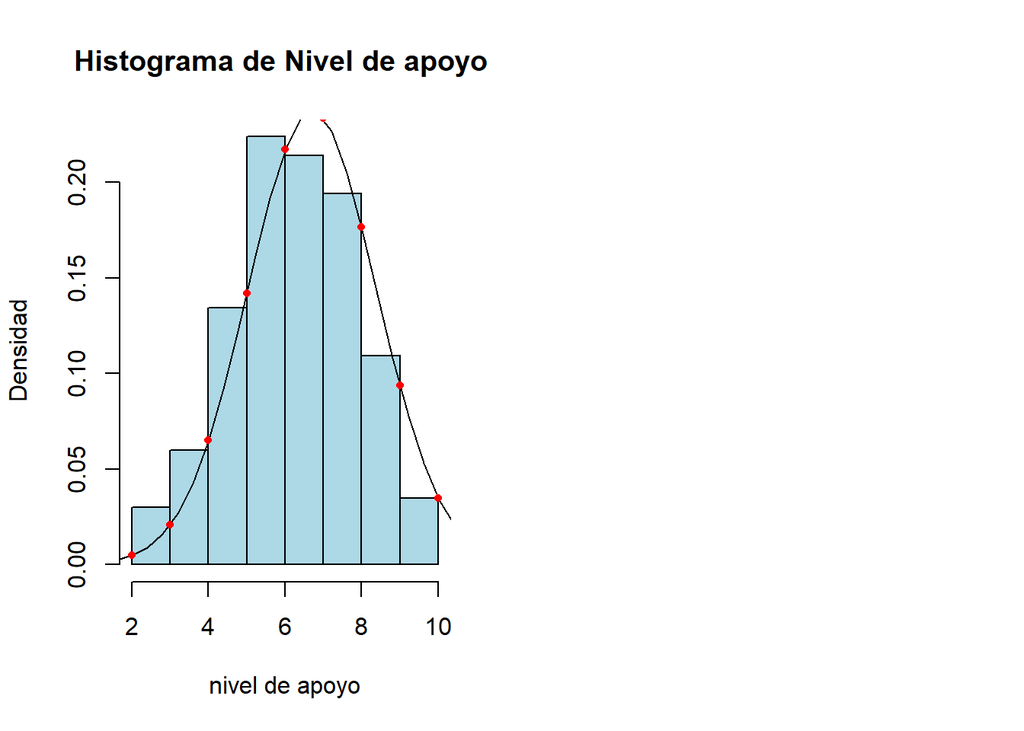

```r
op=par(mfrow=c(1,2))

hist(datos$apoyo, breaks=10, freq = FALSE, main="Histograma de Nivel de apoyo ",xlab = "nivel de apoyo",ylab = "Densidad", col = "lightblue")
curve(dnorm(x, mean(datos$apoyo,na.rm = TRUE), sd = sd(datos$apoyo,na.rm = TRUE)),
      0, 200, 500,
      yaxs = "i", add = TRUE)
points(datos$apoyo, dnorm(datos$apoyo, mean(datos$apoyo,na.rm = TRUE), sd = sd(datos$apoyo,na.rm = TRUE)), ylab = "f(x)", pch = 20,  lwd = 0.1, col = "red")
```

```r
desv_apoy <- rd3(sd(datos$apoyo , na.rm = TRUE))
round(desv_apoy,digits=2)
```

```
## [1] 1.68
```

```r
cv_apoy<-rd3((sd(datos$apoyo, na.rm = TRUE)/mean(datos$apoyo, na.rm = TRUE)))
round(cv_apoy,digits=2)
```

```
## [1] 0.25
```

### **Primera pregunta**

- *¿Cuál es la probabilidad de encontrar a un estudiante de bioingeniería, dado que la persona esta en el piso 6? .*

Probabilidad de que el estudiante sea de Bioingeniería

```r
round((nrow(filter(datos, carrera=="Bioing")))/201,2)
```

```
## [1] 0.14
```

Probabilidad de que el estudiante este descansando o estudiando en el Piso 6

```r
round((filter(reg_lugar, name=="Piso6")$frec)/201,2)
```

```
## [1] 0.61
```

Probabilidad de que el estudiante este en el Piso 6 y sea de bioingeniería

- Cantidad de estudiantes en el piso 6

```r
filter(reg_lugar, name=="Piso6")$frec
```

```
## [1] 123
```

- Cantidad de estudiantes de Bioingeniería en el piso 6

```r
nrow(filter(filter(datos1, DeEn_Piso6 > 0), carrera=="Bioingeniería"))
```

```
## [1] 20
```

```r
round(20/123,2)
```

```
## [1] 0.16
```

$P(A∕B)=\frac{P(A∩B)}{P(B)}$

```r
round(0.16/0.61,2)
```

```
## [1] 0.26
```

La probabilidad de encontrar un estudiante de bioingeniería cuando se busca en el piso 6 es

### **Segunda pregunta**

**Modelo Binomial Negativo** - *De la variable de tipo categórica nominal, aumento de lugares de descanso, donde se concluye que la mayoría desea aumenta en espacios en áreas de descanso y verdes con un valor de 55.72%, un 24.38% desea solo áreas de descanso, un 18.91% desea solo áreas verdes y un 1% no desea ningun aumento.*

```r
table(datos$aumentos)
```

```
##
##            No, ninguna              Si, ambas Solo áreas de descanso
##                      2                    112                     49
##      Solo áreas verdes
##                     38
```

```r
round(prop.table(table(datos$aumentos))*100,2)
```

```
##
##            No, ninguna              Si, ambas Solo áreas de descanso
##                   1.00                  55.72                  24.38
##      Solo áreas verdes
##                  18.91
```

¿Cuál es la probabilidad de tener que encuestar a 20 estudiantes para obtener al “octavo” estudiante que prefiera solo áreas de descanso

X: Número de casos totales

k: Casos de exito

p: Probabilidad de exito por caso

```r
dnbinom(20-8,10,0.2438)
```

```
## [1] 0.007624669
```

### **Tercera pregunta**

```r
round(nrow(filter(datos, comodidad >= 9))/201, 2)
```

```
## [1] 0.08
```

¿Cual es la probabilidad de que el decimo estudiante entrevistado sea un promotor?

```r
round(dgeom(9, 0.08),2)
```

```
## [1] 0.04
```

## 11. Conclusiones

En la investigación realizada pudimos lograr cada uno de los objetivos que nos propusimos, tanto generales como específicos, tales como:

Saber el indicador NPS general percibido por los estudiantes de utec, en donde relacionamos 4 variables que se encuentran en una escala del 1 al 10, lo que nos permite relacionarla, dichas variables son: Accesibilidad, comodidad, concentración y apoyo. Estas coinciden en magnitud en cuanto a sus distribuciones, presentan como moda el indicador 6 y 7; además, si juntamos los datos que repsondieron entre 1 y 6 (“detractores”), estos se convierten en una mayoria por la cual podemos concluir que el indicador NPS en cuanto a las areas de descanso o areas verdes en Utec esta dentro del intervalo de los “detractores” (1-6). Cabe aclarar que esto es evaluando en cuanto accesibilidad, comodidad, concentracion y apoyo percibido.

También logramos saber que lugar es el más transcurrido en la universidad para descansar y/o estudiar, el cual son aulas libres con 130 respuestas de las 611 totales, podemos inferir que esto es debido a que las aulas se han convertido en un lugar cálido con accesos a corriente y que permite una libre conversación; algunas de estas características tambien las comparten los otros dos lugares que se encuentran muy cerca, como lo es el piso 6 y la sala de estudio en el piso 1.

Asimismo, determinamos el tiempo aproximado que pasan los estudiantes en las áreas de descanso y estudio, obteniendo como resultado 9.47 horas; además, logramos saber a partir de una pregunta en nuestro cuestionario que la comodidad de esta áreas para los estudiantes tiene una moda de 6, y el intervalo con mayor cantidad de datos está entre 4 y 7 en una escala de indicador NPS, esto nos indica que la mayoría de estudiantes se convierten en “detractores” en cuanto a la comodidad de estos espacios, recordemos que los detractores son los que que encuentra entre un indice de 1 a 6 NPS.

Igualmente, cabe mencionar que la cantidad de areas establecidas en el campues de la universidad NO son suficientes para el alumnado, en nuestra variable “aumentos” podemos percibir la respuesta de los estudiantes ante esta pregunta, tomando como respuesta mayoritaria en gran cantidad que SÍ les gustaria tener más areas, tanto de descanso como áreas verdes en la universidad, dado que esta obtuvo 112 respuestas de las 201 en total, lo que nos da mas de un 50 % en esta altenativa.